Traineeship2: Effective Sample Size for Network Autocorrelation Model

**Afra Kilic**  
**Supervisor: dr. ir. Joris Mulder**  
**15-06-2022**  
In statistics, the amount of information contained in the data is very elementary for every kind of statistical inferences like parameter estimation, hypothesis testing or model selection. In the context of univariate Gaussian model, sample size is considered to represent the amount of information (Cox and Hinkley 1974; Welsh 1996) and it is well defined if the observations are i.i.d. However, in non-i.i.d settings (e.g., repeated measures or meta-analysis) or for vector observations, sample size is not a true metric to define amount of information in the data.

Hence, It is very important to quantify the available amount of info in the data. Effective Sample Size (ESS), is a way of quantifying the amount of information in the data. ESS, by definition is an estimate of sample size required to achieve the same level of precision in statistical inferences if the observations are i.i.d.

The aim of the present study is to estimate the effective sample size for Bayesian Estimation of Network Autocorrelation Model (NAM), where the observations are correlated with each other because of the Network Effect. NAM is used to analyze/quantify/identify the network effect in a given network for a given specific theory of interpersonal influence while controlling for other possible factors. The other way around, NAM is also used to control for network effect to estimate other factors’ effect on an output variable. Thus, as network effect and density increase we expect higher correlation among the observations which implies lower level of ESS.

To estimate Effective Sample Size for Bayesian NAM, we used the ESS model proposed by Faes et. al (2012), where they estimated the ESS to devise a new denominator degrees-of-freedom for fixed-effects testing. We implemented that model into Bayesian Estimation of NAM model.

Overview of the ESS model (Faes et. al, 2012)

*Please see the original paper for more detailed derivation of the model.*

Faus et. al (2012) used a general linear mixed model (i.e. $Y_i = X_i \beta + Z_ib_i + \epsilon_i$), where $\beta$ is a vector of population-average regression coefficients called *fixed effects* Consider the Gaussian case, the fixed-effects parameter $\beta$ can be estimated as follow:

$$\hat{\beta} = (\sum_{i = 1}^{N} X_i^{'}V_i^{-1}X_i)^{-1} \sum_{i = 1}^{N} X_i^{'}V_i^{-1}X_i$$
This is an unbiased estimate for $\beta$ where the mean is the response is correctly specified even if the the variance $V_i$ is misspecified.

Where the $V_i$ is specified properly, the variance of $\beta$ is equal to:

$$\hat{Var}(\hat{\beta}) = (\sum_{i = 1}^{N} X_i^{'}V_i^{-1}X_i)^{-1}$$
This equation, the variance of $\beta$ shows the amount of information contained in the data about the parameter $\beta$ as it is actually the inverse of the Fisher information.

When the observations are independent from each other, $\beta$ variance would be calculated as:

$$\tilde{Var}(\hat{\beta}) = (\sum_{i = 1}^{N} X_i^{'}W_i^{-1}X_i)^{-1}$$
where $W_i = diag(V_i)$, a diagonal matrix with the same values on the diagonal as $V_i$. So, the notation $\tilde{Var(.)}$ refers to the quantity under independence.

Based on these two equations, we derive the effective sample size for a parameter $\beta_k$ in a general model by estimating the weight $w$ to be given to each observational unit as follows:

$$\tilde{Var}^w(\hat{\beta_k}) = [(\sum_{i = 1}^{N} X_i^{'}W_i^{-1}X_i)^{-1}]_{kk}$$

So, the variance of $\beta_k$ in the weighted data, under the assumption of independence, $\tilde{Var}^w(\hat{\beta_k})$ equals to the variance in original data under the assumption of dependence $[\hat{Var}(\hat{\beta_k})]$. Thereby, the effective sample size is defined as:
$$\tilde{N}(\beta_k) = w\sum_{i = 1}n_i,$$
where the weight is:

$$w = \frac{\tilde{Var}(\tilde{\beta_k})}{\hat{Var}(\hat{\beta_k})}$$

Bayesian Estimation of Network Autocorrelation Model and ESS

The First Order Network Autocorrelation Model

Formally, the network autocorrelation model is expressed as:

$$\begin{align*}
y = \rho Wy + X \beta + \epsilon, \qquad \epsilon &\sim {\sf Norm}(0, \sigma^2I_g)
\end{align*}$$
Where

- **$y$**: $(g\times 1)$ -vector of values of a dependent variable for the $g$ network actors
- **$X$**: $(g\times k)$ -matrix of values for the actors on k covariates
- **$\beta$**: $(k\times 1)$ -vector regression coefficients
- **$I_g$**: $(g\times g)$-identity matrix
- **$\epsilon$**: $(g\times1)$ -vector containing independent and identically normally distributed error terms with zero mean and variance of $\sigma^2$.
- **$W$**: given $(g\times g)$ - connectivity matrix representing social ties in a network, with $W_{ij}(i, j \in \{1, ..., g\})$ referring the degree of influence of actor $j$ on actor $i. Please note that connectivity matrix is different from diagonal matrix in ESS model.
- **$\rho$**: the parameter quantifying the social influence for a given $y, W, X$

Applying the Effective Sample Size Model to the First Order Network Autocorrelation Model

Rewriting the Network Autocorrelation Model in linear regression format to apply the ESS model to NAM:

$$\begin{equation}
\begin{split}
Y = \rho Wy + X \beta + \epsilon, \qquad \epsilon &\sim {\sf N}(0, \sigma^2I_k) \\
\\
Y - \rho Wy = X \beta + {\sf N}(0, \sigma^2I_k) \\
\\
(I_k - \rho W)Y = X\beta + {\sf N}(0, \sigma^2I_k) \\
\\
(I_k - \rho W)^{-1} (I_k - \rho W) Y = (I_k - \rho W) ^ {-1} (X\beta + {\sf N}(0, \sigma^2I_k)) \\
\\
Y = (I_k- \rho W) ^{-1} X\beta + {\sf N}(0, (I_k - \rho W) ^{-1} \sigma^2 I_k ((I_k - \rho W) ^{-1}) ^ {'})
\end{split}
\end{equation}$$

In a more simplified way:

$$\begin{equation}
\begin{split}
Y = (I_k- \rho W) ^{-1} X\beta + {\sf N}(0, \sigma^2 (I_k - \rho W) ^{-1} ((I_k - \rho W) ^{-1}) ^ {'}) \\
\\
\\
Y = (I_k - \rho W) ^{-1} X \beta + {\sf N}(0, \sum\rho,\sigma^2) \quad\text{where},\\
\\
\qquad \sum\rho,\sigma^2 = \sigma^2 (I_k - \rho W) ^{-1} ((I_k - \rho W) ^{-1}) ^ {'}, \qquad
\text {and}
\qquad X_\rho = (I_k - \rho W) ^{-1} X \\
\\
\\
\end{split}
\end{equation}$$

Finally we can rewrite the euation as following:

$$\begin{equation}
\begin{split}
\\
Y = X_\rho \beta + \epsilon, \qquad \epsilon &\sim {\sf N}(0, \sum\rho,\sigma^2)
\end{split}
\end{equation}$$

After rewriting NAM, $\sum\rho,\sigma^2$ is considered as $V_i$ in the ESS model, the variance matrix which can have values in its off-diagonals. Thus, $Var(\beta)$ can be estimated when $\sum\rho,\sigma^2$ is specified as follows:

$$\hat{Var}(\hat{\beta}) = [X_{\rho}^{'}(\sum\hat{\rho},\hat{\sigma^{2}})^{-1}X_{\rho}]^{-1}$$
$\hat{Var}(\hat{\beta})$, the variance of $\beta$ shows the amount of information contained in the data about the parameter $\beta$ as it is actually the inverse of the Fisher information. When the observations are independent from each other, $\beta$ variance would be calculated as:

$$\tilde{Var}(\hat{\beta}) = [X_{\rho}^{'}[diag(\sum\hat{\rho},\hat{\sigma^{2}})^{-1}]X_{\rho}]^{-1}$$
where $diag(\sum\hat{\rho},\hat{\sigma^{2}})^{-1}$, a diagonal matrix with the same values on the diagonal as $\sum\hat{\rho},\hat{\sigma^{2}}$. So, the notation $\tilde{Var(.)}$ refers to the quantity under independence.

Based on these two equations, we derive the effective sample size for a parameter $\beta_k$ in a general model by estimating the weight $w$ to be given to each observational unit as follows:

$$\tilde{Var}^{w}(\hat{\beta_k}) = [X_{\rho}^{'}[diag(\sum\hat{\rho},\hat{\sigma^{2}})^{-1}]X_{\rho}]^{-1}_{kk}$$
In other words, for a general model **weighted** $Var(\hat{\beta_k})$ will be the $kk_{th}$ element of $Var(\hat{\beta_k})$ matrix. So we can calculate the effective sample size $n_k^E$ as:

$$n_k^E = w_k \times n \\
\\
where, \qquad w_k= \frac{\tilde{Var}^w(\tilde{\beta_k})}{\hat{Var}^w(\hat{\beta_k})}\\
\\
\text{and}\quad n \quad \text{is the original sample size.}$$

The Simulation

Package Installation

First, the required packages have to be loaded. You can access to the overview of the packages on Github. The simulation data will be generated by using the package sna. Then, by using these generated data, Bayesian NAM will be fitted by using the package banam.

```r
install.packages("devtools")
devtools::install_github("jomulder/BANAM")
install.packages("sna")
```

Rho Sequence

To observe how the $n_k^E$ behaves across different $\rho$ values, let’s create a $\rho$ sequence consisting 50 different $\rho_s$:

```r
rho_s <- seq(0.001, 0.9, length.out=50)
```

Density Sequence

To observe how the $n_k^E$ behaves across different network density values, let’s create a density sequence consisting 5 different density values up to 0.5:

```r
d_s <- seq(0.001, 0.5, length.out=5)
```

Creating Matrix For Effective Sample Size

$n_k^E$ matrix creation to store estimated $\beta$ coefficients:

```r
effective_n <- matrix(c(rep(NA, 3)), ncol = 3, nrow = 1)

colnames(effective_n) <- c("Beta0", "Beta1", "Beta2")

rowname <- matrix(c(rep(NA, 250)), ncol = length(d_s), nrow = length(rho_s))
for (i in 1:length(d_s)){
  for(j in 1:length(rho_s)){
  rowname[j,i] <- paste("rho =", round(rho_s[j], digits = 2), "density =", round(d_s[i], digits = 2))
  }
}
```

Loop for the Simulation

data generation

The following loop generates NAM data by using the package sna for each $\rho$ and network density pairs which is 250 different NAM data in total. While $\rho$ and network density values are changing across 250 different data sets,

- $\beta_0 = 3$
- $\beta_1 = 0.5$
- $\beta_2 = 0.4$
- $\sigma^2 = 1$
- $n = 50$

are the same for all data sets. set.seed is also always the same to prevent the variance coming from randomization.

fitting the model

- *highlighted parts of the text refer to the variables in the code*

After generating data for each $rho$ and network density pair, We fit the Bayesian Network Autocorrellation Model by using banam function from the package BANAM. we get the $\hat{\beta_k}$ (beta_hat), $\hat{\rho}$ (rho_hat), and $\hat{\sigma^2}$ (sigma2_hat) estimates from the fitted model. With these estimates, $\hat{Var}(\hat{\beta})$ ((beta)) and $\hat{Var}(\hat{\beta})$ (beta_tilde) matrices are calculated. $kk_th$ elements of these matrices ($\hat{Var}(\hat{\beta})$ and $\tilde{Var}(\hat{\beta})$) are corresponding to weighted variances of $\hat{\beta_k}$}. To calculate $w_k$, $\tilde{Var}^w(\tilde{\beta_k})$ is divided by ${\hat{Var}^w(\hat{\beta_k})}$.

- For instance, the algorithm calculates $w_0$ (for the intercept coefficient) as (beta_tilde[1,1] / beta[1,1]). Then, to calculate $n_k^0$ (effective sample size for the intercept coefficient’ $\beta_0$), we multiply $n_k^0$ by $n$ which is 50 in our case.

After calculate $n_k^E$ for $\beta_0$, $\beta_1$ and $\beta_2$ coefficient for each data set, the estimated $n_k^E$ are stored in effective_n.

```r
 for (i in 1:length(d_s)){
    for(j in 1:length(rho_s)){

    set.seed(1)
    library(sna)
    library(BANAM)

    beta <- c(3,.5,.4)
    sigma2 <- 1
    n<-50

    #data generation
    Wadj <- sna::rgraph(n, tprob = d_s[i], mode = "graph")
    W <- sna::make.stochastic(Wadj, mode = "row")
    X <- matrix(c(rep(1, n), rnorm(n*2)), nrow=n, ncol=3)

    y <- c((solve(diag(n) - rho_s[j]*W))%*%(X%*%beta + rnorm(n)))
    y <- y - mean(y)

    X_rho <- (solve(diag(n) - rho_s[j]*W)) %*% X

    #BAYES ESTIMATION
    best <- banam(y, X, W)

    cat("\014") #to clear banam output in HTML output

    #Estimates
    beta_hat <- best$beta.mean
    rho_hat <- best$rho.mean
    sigma2_hat <- best$sigma2.mean
    #variance calculation
    sum <- sigma2_hat*(solve(diag(n)-rho_hat*W)%*%t(solve(diag(n)-rho_hat*W)))
    #Beta variance estimation under dependency
    beta <- solve(t(X_rho) %*% solve(sum) %*% X_rho)

    #Beta variance estimation under in-dependency
    beta_tilde <- solve(t(X_rho) %*% solve(diag(diag(sum))) %*% X_rho)

    n_e_B0 <- (beta_tilde[1,1] / beta[1,1]) * n
    n_e_B1 <- (beta_tilde[2,2] / beta[2,2]) * n
    n_e_B2 <- (beta_tilde[3,3] / beta[3,3]) * n
    n_e <- c(n_e_B0, n_e_B1, n_e_B2)
    effective_n <- rbind(effective_n, n_e)

    gdata::keep(effective_n, rho_s, d_s)

    }
 }
```

Adjustment on Effective Sample Size Matrix

```r
effective_n <- effective_n[c(-1),]
rownames(effective_n) <- as.vector(rowname)
```

Visualizing the Results

The Intercept ($\beta_0$) Coefficient Effective Sample Size

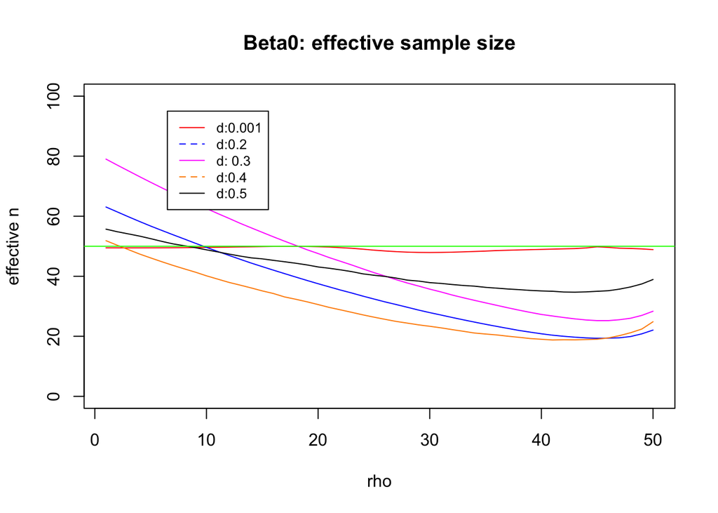

```r
plot(c(1:50), effective_n[, 1][1:50], type = "l", ylim = c(0,100), col = "red", main = "Beta0: effective sample size", ylab = "effective n", xlab = "rho")
lines(effective_n[, 1][51:100], col = "blue")
lines(effective_n[, 1][101:150], col = "magenta")
lines(effective_n[, 1][151:200], col = "darkorange")
lines(effective_n[, 1][201:250])
abline(h = 50, col = "green")
legend(6.5, 95, legend=c("d:0.001", "d:0.2","d: 0.3", "d:0.4", "d:0.5"),
       col=c("red", "blue", "magenta", "darkorange", "black"), lty=1:2, cex=0.8)
```

For the intercept coefficient, $n^E$ is decreasing with higher $\rho$ values but it is not consistent with network density values. In other words, to estimate intercept coefficient bigger sample size is needed when $\rho$ is high. When the network density, the connectedness level between the people in a given network, is very close to 0, $n_0^E$ is almost the same with $n$. However, decrease in $n_0^E$ does not show a consistent trend with increasing density level.

$\beta_1$ Effective Sample Size

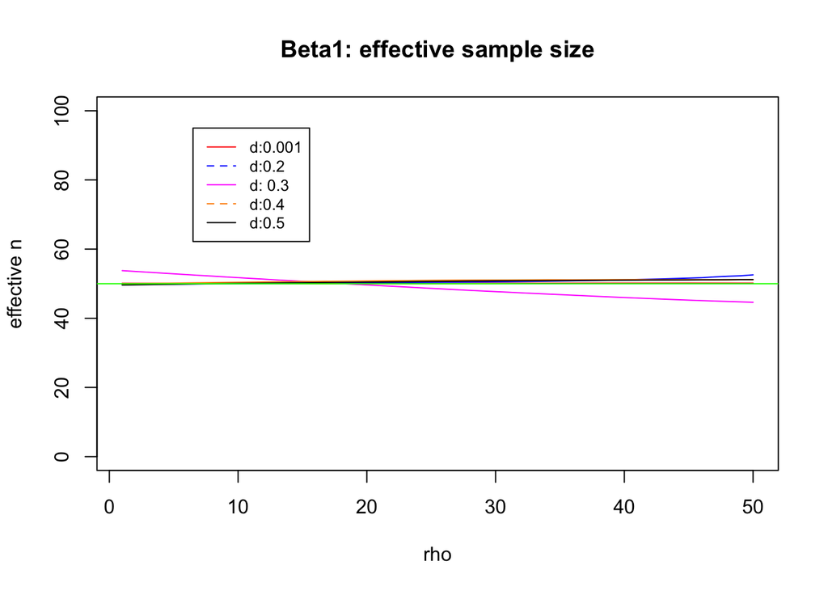

```r
plot(c(1:50), effective_n[, 2][1:50], type = "l", ylim = c(0,100), col = "red", main = "Beta1: effective sample size", ylab = "effective n", xlab = "rho")
lines(effective_n[, 2][51:100], col = "blue")
lines(effective_n[, 2][101:150], col = "magenta")
lines(effective_n[, 2][151:200], col = "darkorange")
lines(effective_n[, 2][201:250])
abline(h = 50, col = "green")
legend(6.5, 95, legend=c("d:0.001", "d:0.2","d: 0.3", "d:0.4", "d:0.5"),
       col=c("red", "blue", "magenta", "darkorange", "black"), lty=1:2, cex=0.8)
```

$\beta_2$ Effective Sample Size

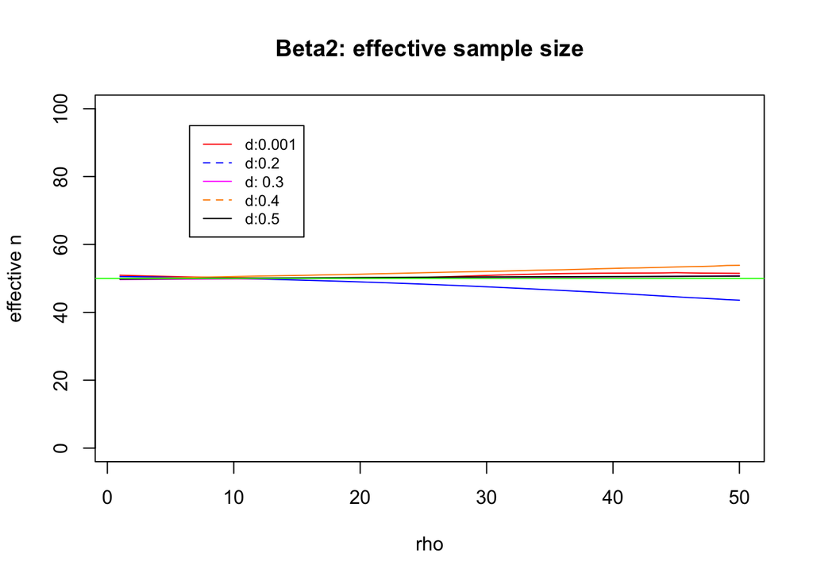

```r
plot(c(1:50), effective_n[, 3][1:50], type = "l", ylim = c(0,100), col = "red", main = "Beta2: effective sample size", ylab = "effective n", xlab = "rho")
lines(effective_n[, 3][51:100], col = "blue")
lines(effective_n[, 3][101:150], col = "magenta")
lines(effective_n[, 3][151:200], col = "darkorange")
lines(effective_n[, 3][201:250])
abline(h = 50, col = "green")
legend(6.5, 95, legend=c("d:0.001", "d:0.2","d: 0.3", "d:0.4", "d:0.5"),
       col=c("red", "blue", "magenta", "darkorange", "black"), lty=1:2, cex=0.8)
```

$n_1^E$ and $n_2^E$ are almost the same with $n$ across different level of $\rho$ and density values. So, these graphs tell us that the amount of info contained in the data is the same for different $\rho$ and density values, thus, the coefficients $\beta_1$ and $\beta_2$ is unbiased across different $\rho$ and density values. However, because the X values were generated totally randomly, the observations are almost totally independent from each other already, which makes $\tilde{Var}(\hat{\beta})$ equals to $\hat{Var}(\hat{\beta})$. In return, $n^E$ for $\beta$ coefficients (other than the intercept value) are the same with $n$.

Discussion of the Results

All in all, we have tried to calculate the $n^E$ for $\beta$ coefficients of NAM model. However, the ESS model proposed by Faes et. al(2012) is not suitable to be applied to NAM model in this way because we actually could not observe the dependency between the observations by generating the data.

References

- Cox, D. R., and Hinkley, D. V. (1974), Theoretical Statistics, London:Chapman&Hall.
- Welsh, A. H. (1996), Aspects of Statistical Inference, New York:Wiley.
- Faes, C., Molenberghs, G., Aerts, M., Verbeke, G., & Kenward, M. G. (2009). The Effective Sample Size and an Alternative Small-Sample Degrees-of-Freedom Method. The American Statistician, 63(4), 389–399. https://doi.org/10.1198/tast.2009.08196